# BMB 521: Data analysis in R

12 March 2024

# 1 Background

The goal of this tutorial is to give you a quick intro into the theory and practice of amplicon sequencing data and how to go from raw sequencing data to publication-quality figures/analysis. We will be focusing on 16S rRNA amplicon data, but you will see in later sessions, many of these concepts and techniques are relevant to other data types and fields!

For this session, we are going to emulate a fairly common scenario. The background of the data we will analyze today is that it is derived from gnotobiotic mice which were colonized using human samples from before and after a weight loss diet intervention. As is often the case in gnotobiotic fecal transplant experiments, we examined host phenotypes. Mice that received post-diet microbiomes demonstrated rapid and sustained weight loss (Panel A). Despite consuming similar amounts of food (Panel B), we found that the fecal caloric content was higher in post-diet mice suggesting a defect in nutrient absorption (Panel C). We used 16S rRNA amplicon sequencing of the V4 region to characterize the recipient microbiome to try to map which organisms could be responsible for the weight loss phenotype. We will be examining a subset of 3 mice from the pre-diet and post-diet groups at 4 time points across the experiment **to generate a hypothesis about which microbes in the post-diet microbiota are responsible for weight loss**.

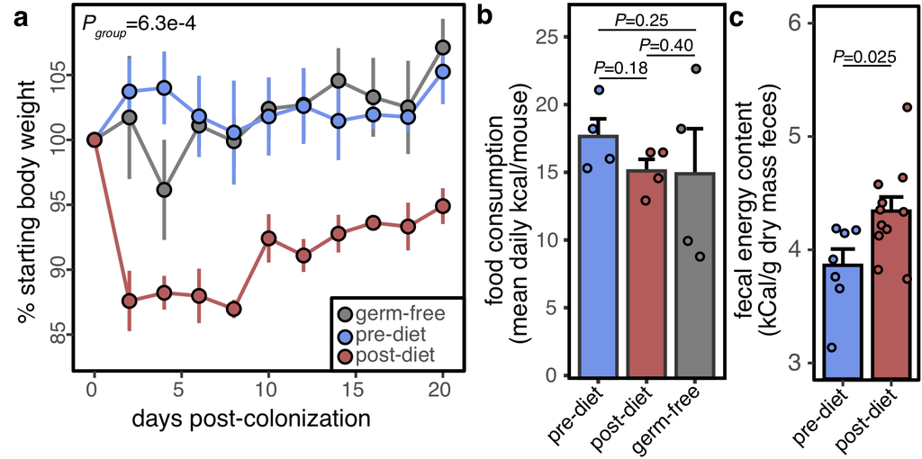

**Figure 1. (A)** Weight loss in recipient mice. **(B)** Food consumption in recipient mice. **(C)** Fecal caloric content.

# 2 Preparing For Class

Before our session, please complete the sections below. The goal is for you to have downloaded all of the data and software ahead of time so we can focus on concepts and data interpretation rather than troubleshooting. That being said… installing software is often the most difficult part of bioinformatics, so please email `jordan.bisanz@psu.edu` if you run into difficulties. You will need access to a mac/windows/Linux machine with at least ~150 MB of free storage. If you can’t access a computer, please let me know ahead of time and I can make an arrangement for you to remotely access a R studio session via your web browser.

## 2.1 Installing R and R Studio

We will be making use of the R programming language which is commonly used across many fields for statistical analysis. To begin, please install and/or update to version of R (4.3.2 by downloading from the following [link](https://cran.rstudio.com/). R is commonly accessed through an easy-to-use interface called R studio. This can be downloaded [here](https://posit.co/download/rstudio-desktop/). R and many of the packages you would use for data analysis are updated on a regular basis, **please ensure you have the latest version of R.**

If you are not familiar with R, it is an extremely useful tool for analyzing and visualizing data. If you are not familiar with it, please watch these videos before our class:

- [Introduction to R Programming with Data Camp](https://www.youtube.com/watch?v=HkNFn6eosaU)
- [Getting started with R and RStudio](https://www.youtube.com/watch?v=lVKMsaWju8w&t=3s)
- If you are interested in learning more R, I recommend [this book](https://www.amazon.com/Data-Science-Transform-Visualize-Model/dp/1491910399/ref=sr_1_9?dchild=1&keywords=tidyverse&qid=1620329413&s=books&sr=1-9).

To ensure you have successfully installed the software, please open R studio and type the following code into your console:

```r
R.Version()$version.string
```

The expected output that should be reported is: `R version 4.3.2 (2023-10-31)`.

## 2.2 Installing Required Packages

Generally speaking, most packages for microbial ecology exist in 3 places: CRAN, Bioconductor, and Github. CRAN is the main R repository from which packages can be installed using `install.packages()`. Bioconductor is a repository specializing in bioinformatics. Bioconductor packages are installed via its own package (available from CRAN) called BiocManager which has a function called `BiocManager::install()`. Finally, the newest versions of packages or in-development packages are often found on github which can be installed using a package called devtools which offers `devtools::install_github()`. To install the required packages, copy and past the code below line by line into your R session. If asked to compile type `yes` and if asked to update packages types `no`.

```r
install.packages("tidyverse") # A group of related packages to facilitate a wide variety of useful tasks including plotting
install.packages("vegan") # A commonly used ecology package offering diversity calculations and statistical tests
install.packages("ape") # A package for phylogenetic analysis offering several useful functions for microbial ecology
install.packages("lme4") # A package for advanced statistical testing
install.packages("lmerTest") # A package for advanced statistical testing

install.packages("BiocManager") # The package manager for Bioconductor
BiocManager::install("dada2") # A one-stop-shop for processing amplicon data
BiocManager::install("phyloseq") # A R package for microbiome analysis

install.packages("devtools") # A multi-purpose tool for developing packages
devtools::install_github("jbisanz/qiime2R") # A multi-purpose microbiome import/processing package written by yours truly
```

After you have installed all of the above packages, it is a good idea to try loading them one by one as below. If a package fails to load, read the error message and then try to reinstall. Please contact me if there are issues which you can’t resolve.

```r
library(tidyverse)
library(dada2)
library(phyloseq)
library(ape)
library(vegan)
library(qiime2R)
library(lme4)
```

## 2.3 Downloading Data

We will start by creating a new directory for our project using the `dir.create()` function. I am going to place this on my desktop, but you might want to pick somewhere else depending on your computer:

```r
dir.create("~/Desktop/BMMB521_tutorial") #Note: windows users would use dir.create("C:\Users\YourUserName\Desktop\BMMB521_tutorial")
```

Then we can specifically set our working directory to be inside this older as below:

```r
setwd("~/Desktop/BMMB521_tutorial") #Note: windows users would use setwd("C:\Users\YourUserName\Desktop\BMMB521_tutorial")
```

### 2.3.1 Reads

I am providing the sequencing data as a single compressed directory (a gzipped tarball). You could download it via R as below, or using your web browser by copying the link.

```r
download.file("https://github.com/jbisanz/BMS270_SP2021/raw/main/BMS270_SP2021_reads.tar.gz", "BMMB521_reads.tar.gz")
```

Now that we have downloaded the reads, we can unpack the folder as below:

```r
untar("BMMB521_reads.tar.gz")
```

You will now see that a folder called reads has appeared. We can look at them in R using `list.files()`.

```r
list.files("reads")
```

```
##  [1] "MOUSE.G11.Day1_1.fastq.gz"  "MOUSE.G11.Day1_2.fastq.gz"
##  [3] "MOUSE.G11.Day14_1.fastq.gz" "MOUSE.G11.Day14_2.fastq.gz"
##  [5] "MOUSE.G11.Day21_1.fastq.gz" "MOUSE.G11.Day21_2.fastq.gz"
##  [7] "MOUSE.G11.Day7_1.fastq.gz"  "MOUSE.G11.Day7_2.fastq.gz"
##  [9] "MOUSE.G12.Day1_1.fastq.gz"  "MOUSE.G12.Day1_2.fastq.gz"
## [11] "MOUSE.G12.Day14_1.fastq.gz" "MOUSE.G12.Day14_2.fastq.gz"
## [13] "MOUSE.G12.Day21_1.fastq.gz" "MOUSE.G12.Day21_2.fastq.gz"
## [15] "MOUSE.G12.Day7_1.fastq.gz"  "MOUSE.G12.Day7_2.fastq.gz"
## [17] "MOUSE.G21.Day1_1.fastq.gz"  "MOUSE.G21.Day1_2.fastq.gz"
## [19] "MOUSE.G21.Day14_1.fastq.gz" "MOUSE.G21.Day14_2.fastq.gz"
## [21] "MOUSE.G21.Day21_1.fastq.gz" "MOUSE.G21.Day21_2.fastq.gz"
## [23] "MOUSE.G21.Day7_1.fastq.gz"  "MOUSE.G21.Day7_2.fastq.gz"
## [25] "MOUSE.H11.Day1_1.fastq.gz"  "MOUSE.H11.Day1_2.fastq.gz"
## [27] "MOUSE.H11.Day14_1.fastq.gz" "MOUSE.H11.Day14_2.fastq.gz"
## [29] "MOUSE.H11.Day21_1.fastq.gz" "MOUSE.H11.Day21_2.fastq.gz"
## [31] "MOUSE.H11.Day7_1.fastq.gz"  "MOUSE.H11.Day7_2.fastq.gz"
## [33] "MOUSE.H12.Day1_1.fastq.gz"  "MOUSE.H12.Day1_2.fastq.gz"
## [35] "MOUSE.H12.Day14_1.fastq.gz" "MOUSE.H12.Day14_2.fastq.gz"
## [37] "MOUSE.H12.Day21_1.fastq.gz" "MOUSE.H12.Day21_2.fastq.gz"
## [39] "MOUSE.H12.Day7_1.fastq.gz"  "MOUSE.H12.Day7_2.fastq.gz"
## [41] "MOUSE.H21.Day1_1.fastq.gz"  "MOUSE.H21.Day1_2.fastq.gz"
## [43] "MOUSE.H21.Day14_1.fastq.gz" "MOUSE.H21.Day14_2.fastq.gz"
## [45] "MOUSE.H21.Day21_1.fastq.gz" "MOUSE.H21.Day21_2.fastq.gz"
## [47] "MOUSE.H21.Day7_1.fastq.gz"  "MOUSE.H21.Day7_2.fastq.gz"
```

### 2.3.2 Metadata

Now that we have the reads, we need to know which samples they belong to! This is called metadata, and a spreadsheet (in tab separated format) is available to download as below. Note that you could just as easily use excel spread sheets; however, there are some special considerations for reading/writing excel files and they love to auto-convert text to dates which can cause issues.

```r
download.file("https://github.com/jbisanz/BMS270_SP2021/raw/main/metadata.tsv","metadata.tsv")
```

We can now take a quick look at the metadata after reading it in:

```r
read_tsv("metadata.tsv")
```

```
## # A tibble: 24 × 6
##    SampleID Group    MouseID Time_days Read1                            Read2
##    <chr>    <chr>    <chr>       <dbl> <chr>                            <chr>
##  1 G11_d1   pre-diet G11             1 reads/MOUSE.G11.Day1_1.fastq.gz  reads/M…
##  2 G11_d14  pre-diet G11            14 reads/MOUSE.G11.Day14_1.fastq.gz reads/M…
##  3 G11_d21  pre-diet G11            21 reads/MOUSE.G11.Day21_1.fastq.gz reads/M…
##  4 G11_d7   pre-diet G11             7 reads/MOUSE.G11.Day7_1.fastq.gz  reads/M…
##  5 G12_d1   pre-diet G12             1 reads/MOUSE.G12.Day1_1.fastq.gz  reads/M…
##  6 G12_d14  pre-diet G12            14 reads/MOUSE.G12.Day14_1.fastq.gz reads/M…
##  7 G12_d21  pre-diet G12            21 reads/MOUSE.G12.Day21_1.fastq.gz reads/M…
##  8 G12_d7   pre-diet G12             7 reads/MOUSE.G12.Day7_1.fastq.gz  reads/M…
##  9 G21_d1   pre-diet G21             1 reads/MOUSE.G21.Day1_1.fastq.gz  reads/M…
## 10 G21_d14  pre-diet G21            14 reads/MOUSE.G21.Day14_1.fastq.gz reads/M…
## # ℹ 14 more rows
```

### 2.3.3 Taxonomy Database

Finally, we will download a database for taxonomic assignment (if we believe such a thing is valuable). We will be using the RDP database; however, we will discuss alternate (and perhaps better) choices during the tutorial.

```r
download.file("https://zenodo.org/record/4310151/files/rdp_species_assignment_18.fa.gz", "rdp_species_assignment_18.fa.gz")
download.file("https://zenodo.org/record/4310151/files/rdp_train_set_18.fa.gz", "rdp_train_set_18.fa.gz")
```

Stop here before class!